# Лабораторная работа №4

Базовая настройка HTTP-сервера Apache

Гашимова Эсма Эльшан кызы

1132247520@rudn.ru

Российский университет дружбы народов

2026-09-20

# Цели и задачи работы

## Цель лабораторной работы

Приобретение практических навыков установки, базовой настройки и проверки работы HTTP-сервера Apache на виртуальной машине `server`.

Также необходимо настроить виртуальный хостинг для двух DNS-имён и подготовить provisioning-скрипт для автоматизации настройки через Vagrant.

# Процесс выполнения лабораторной работы

## Установка HTTP-сервера

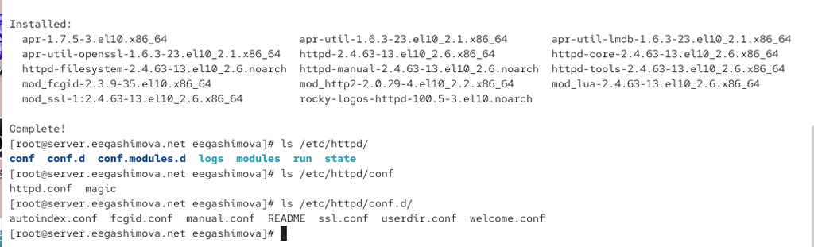

Установка HTTP-сервера и просмотр конфигурации

## Настройка firewalld и запуск Apache

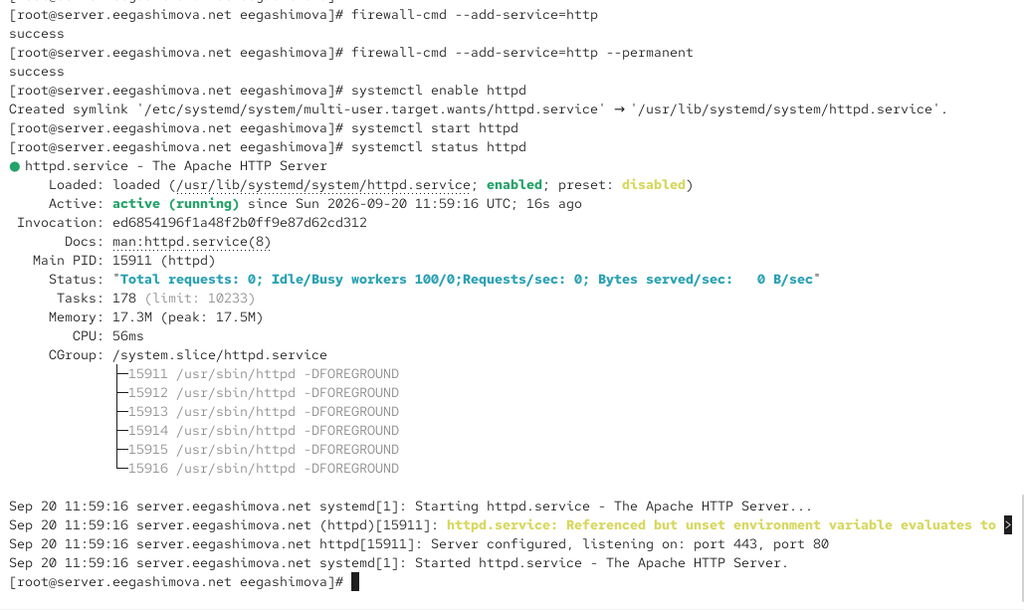

Разрешение HTTP и запуск службы httpd

## Проверка базовой страницы Apache

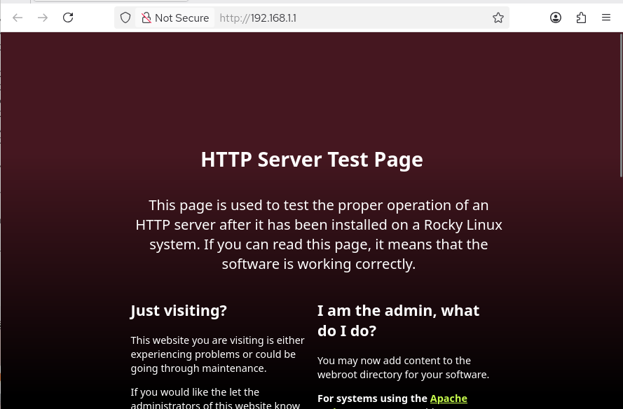

Стандартная тестовая страница Apache

## Анализ журналов Apache

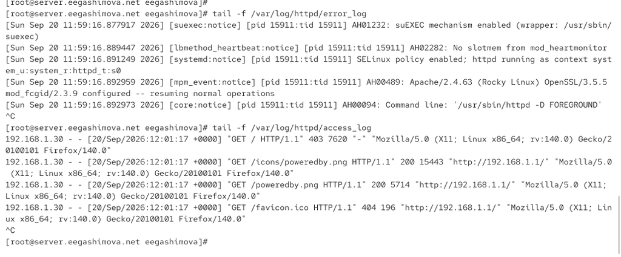

Просмотр access_log и error_log

## Настройка прямой DNS-зоны

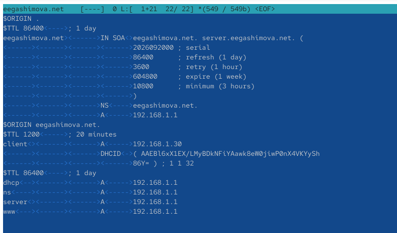

Добавление записи www в прямую DNS-зону

## Настройка обратной DNS-зоны

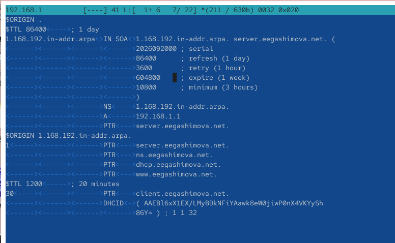

Добавление PTR-записи для www.eegashimova.net

## Виртуальный хост server.eegashimova.net

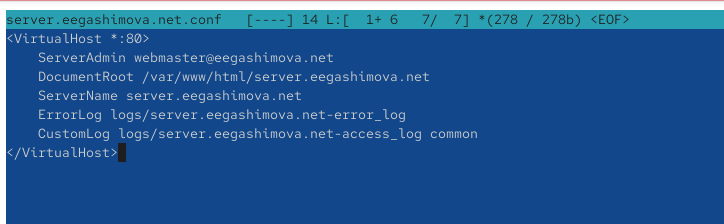

Конфигурация server.eegashimova.net.conf

## Виртуальный хост www.eegashimova.net

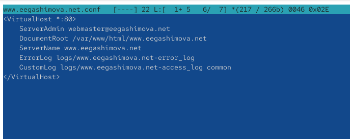

Конфигурация www.eegashimova.net.conf

## Создание веб-контента

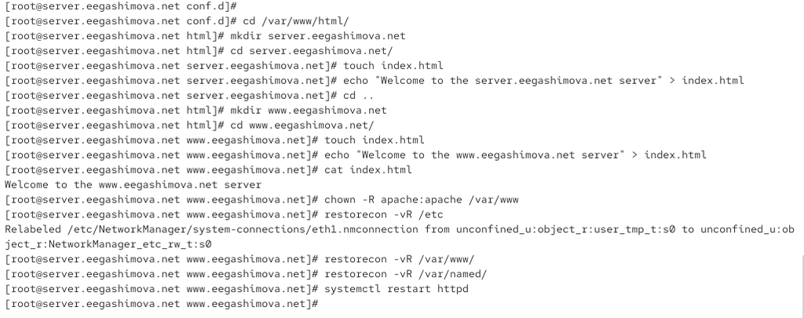

Создание каталогов и index.html для виртуальных хостов

## Проверка server.eegashimova.net

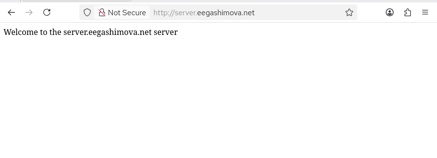

Проверка страницы server.eegashimova.net

## Проверка www.eegashimova.net

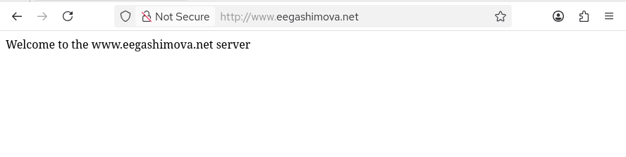

Проверка страницы www.eegashimova.net

## Сохранение конфигурации для Vagrant

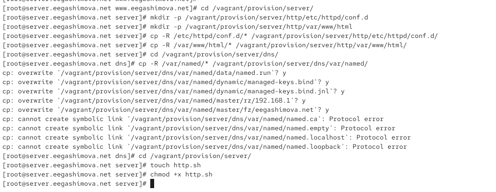

Копирование конфигурации Apache и DNS

## Скрипт автоматической настройки

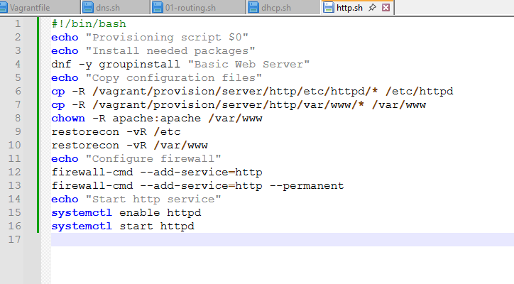

Содержимое скрипта http.sh

# Результаты работы

## Установка и запуск HTTP-сервера

На виртуальной машине `server` был установлен стандартный веб-сервер Apache из группы пакетов `Basic Web Server`.

Служба `httpd` была добавлена в автозагрузку и успешно запущена.

В межсетевом экране `firewalld` был разрешён сервис `http`.

## Проверка работы Apache

Работа HTTP-сервера была проверена с виртуальной машины `client` по адресу:

```
192.168.1.1
```

В браузере отобразилась стандартная тестовая страница Apache.

Также были проанализированы журналы:

```
/var/log/httpd/access_log
/var/log/httpd/error_log
```

## Настройка виртуального хостинга

Были настроены два виртуальных хоста:

```
server.eegashimova.net
www.eegashimova.net
```

Для каждого виртуального хоста был создан отдельный конфигурационный файл Apache и отдельный каталог с веб-контентом.

## Проверка виртуальных хостов

На виртуальной машине `client` была выполнена проверка доступа к обоим DNS-именам.

Для `server.eegashimova.net` отображалась страница:

```
Welcome to the server.eegashimova.net server.
```

Для `www.eegashimova.net` отображалась страница:

```
Welcome to the www.eegashimova.net server.
```

## Автоматизация настройки

Конфигурационные файлы Apache и веб-контент были сохранены в каталоге проекта Vagrant.

Был создан скрипт:

```
/vagrant/provision/server/http.sh
```

Скрипт устанавливает Apache, копирует конфигурационные файлы, настраивает права доступа, восстанавливает контексты SELinux, разрешает HTTP в `firewalld` и запускает службу `httpd`.

## Вывод

В результате выполнения лабораторной работы был установлен и настроен HTTP-сервер Apache.

Была проверена его базовая работа по IP-адресу `192.168.1.1`.

Также был настроен виртуальный хостинг для двух DNS-имён: `server.eegashimova.net` и `www.eegashimova.net`.

Созданный provisioning-скрипт позволяет автоматически воспроизвести настройку HTTP-сервера при развёртывании виртуальной машины `server` через Vagrant.